# Checkpoint 6

Gunnar Goeden & Brett Graham

12/6/2017

## Progress Made

Objective: Demonstrate progress made on the project. Adjustments and improvements to models, cleaning code, updated visuals, etc. Must be completely reproducable.

Summary: Since the last checkpoint, we have created Offensive and Defensive score statistics for each team. These score stats are representative of the teams ability relative to all other teams in the league (they sum to 1) and are updated weekly based on previous game stats. These score stats are also weighted for the opponent of the offensive team in question. We looked to include these score stats in our new models. We have two models using these score stat values; a logged Poisson regression, and a Poisson Normal regression. While these models may not quite considered final yet, they will be the basic structure we use in our final models. We may look to fine tune these models before our final product. Included additionally is a breakdown of variable & model descriptions, variable relationship plots, and *some prediction summary stats for our models*.

## Work Distribution

Both of us worked on and discussed different ways to develop and improve our models using the new score stats data. Brett was responsible for creating the score stats for each team and Gunnar researched various other applications of modeling football data and using Poisson regression models.

## Coding & Models

```
## Linked to JAGS 4.1.0
```

```
## Loaded modules: basemod,bugs
```

```
## [1] 58
```

```r
game_stats_2016 <- createDataframe(2016)
game_stats_2015 <- createDataframe(2015)
game_stats_2014 <- createDataframe(2014)
```

```
## [1] "ERROR: ADJUSTMENT TOO LARGE"
## [1] 176
```

```r
data_2016 <- simplify(game_stats_2016)
```

```
## extract_numeric() is deprecated: please use readr::parse_number() instead
```

```r
game_stats_2014<- game_stats_2014[-176,]
modelDF2016 <- createModelDF(game_stats_2016)
```

```
## extract_numeric() is deprecated: please use readr::parse_number() instead
## extract_numeric() is deprecated: please use readr::parse_number() instead
```

```r
modelDF2015 <- createModelDF(game_stats_2015)
```

```
## extract_numeric() is deprecated: please use readr::parse_number() instead
## extract_numeric() is deprecated: please use readr::parse_number() instead
```

```r
modelDF2014 <- createModelDF(game_stats_2014)
```

```
## extract_numeric() is deprecated: please use readr::parse_number() instead
## extract_numeric() is deprecated: please use readr::parse_number() instead
```

```r
#View(modelDF2016)
```

### Variable Relationships

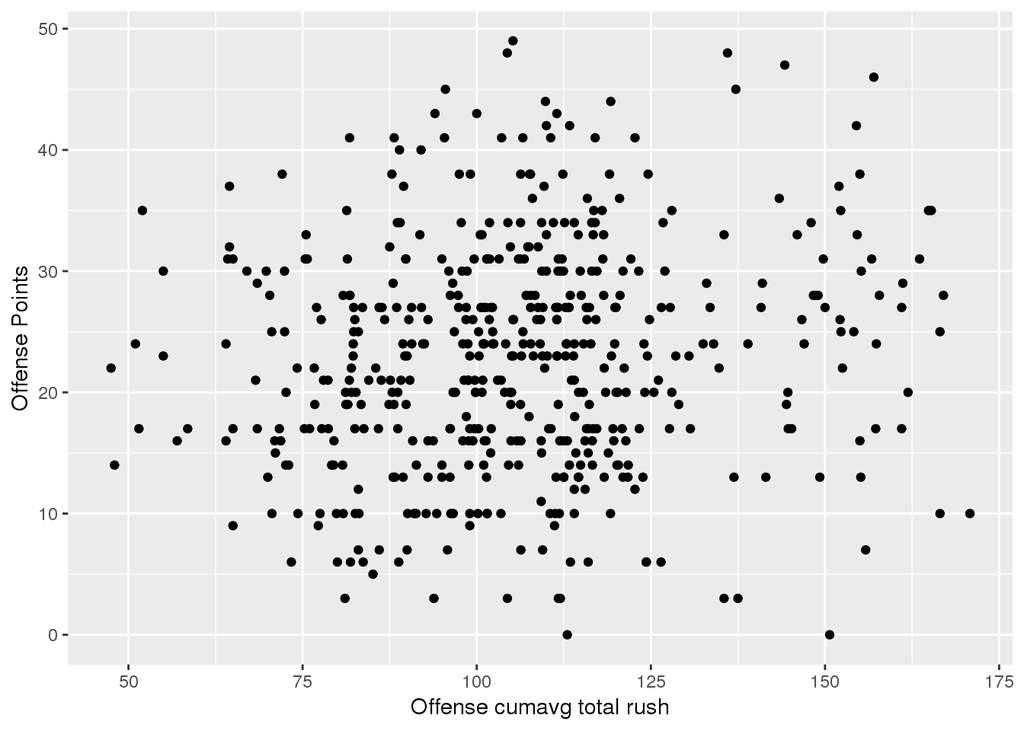

```r
#Create a filtered dataset to ignore early season noise
modelDF2016Filt <- modelDF2016 %>% filter(Week>6)


ggplot(modelDF2016, aes(y=`Offense Points`,x=`Offense cumavg total rush`)) +
  geom_point()
```

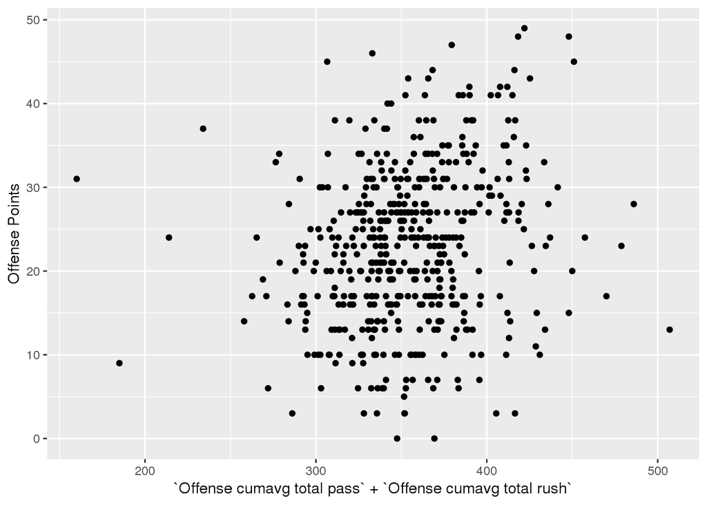

```r
ggplot(modelDF2016, aes(y=`Offense Points`,x=`Offense cumavg total pass` + `Offense cumavg total rush`)) +
  geom_point()
```

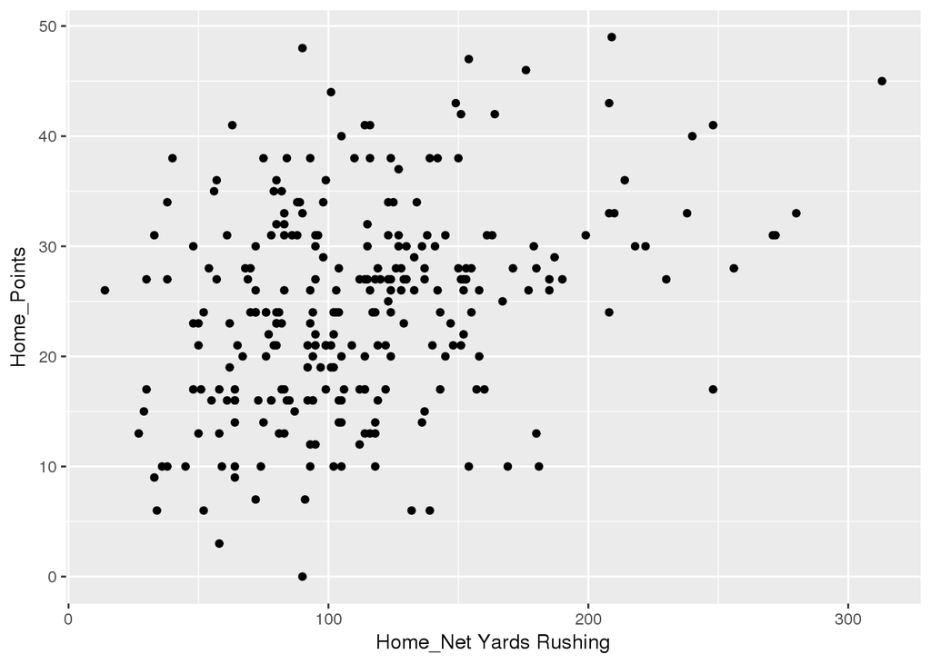

```r
ggplot(data_2016, aes(x=`Home_Net Yards Rushing`,y=`Home_Points`)) +
  geom_point()
```

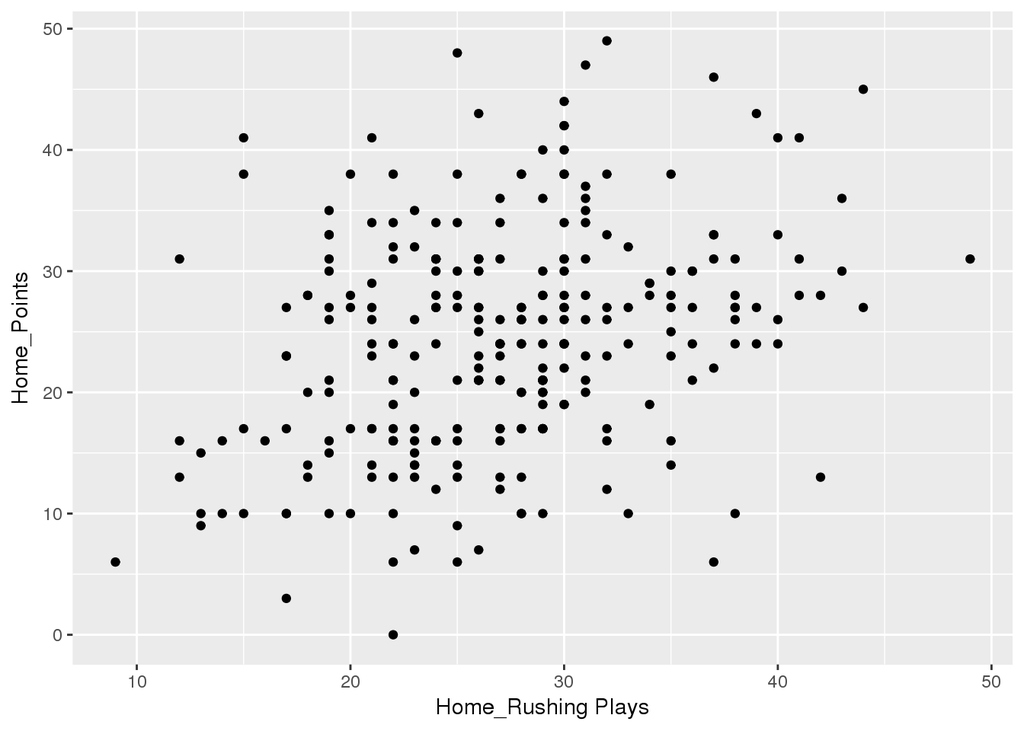

```r
 ggplot(data_2016, aes(x=`Home_Rushing Plays`,y=`Home_Points`)) +
   geom_point()
```

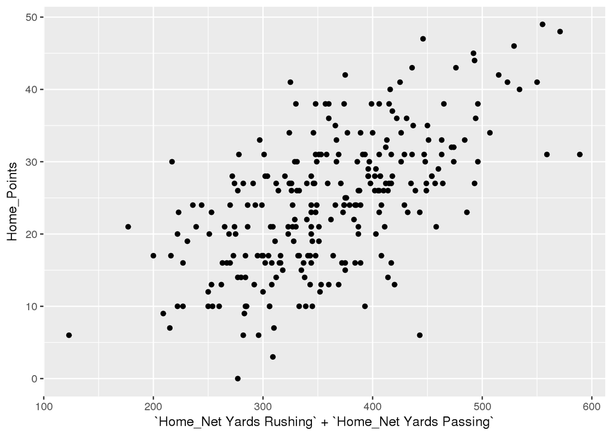

```r
 ggplot(data_2016, aes(x=`Home_Net Yards Rushing`+`Home_Net Yards Passing`,y=`Home_Points`)) +
   geom_point()
```

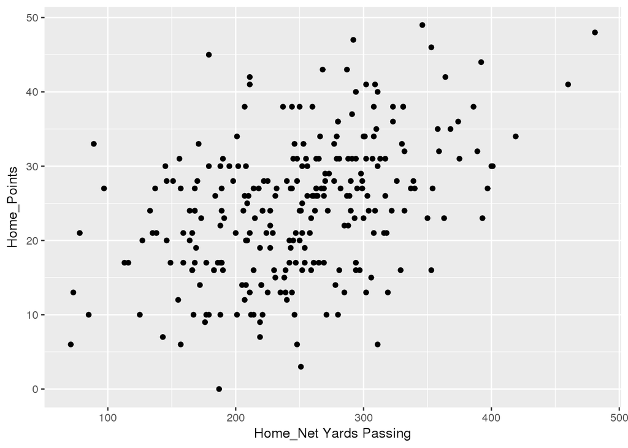

```r
 ggplot(data_2016, aes(x=`Home_Net Yards Passing`,y=`Home_Points`)) +
      geom_point()
```

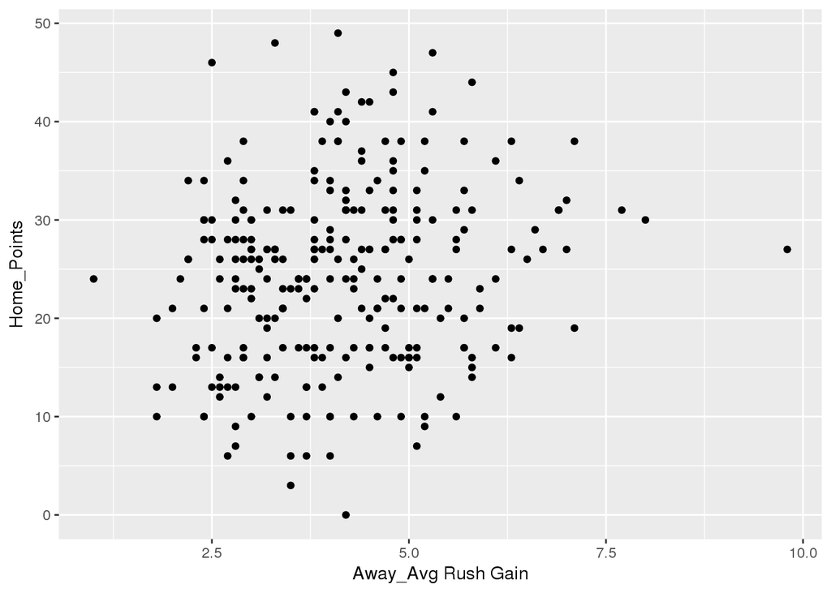

```r
 ggplot(data_2016, aes(x=`Away_Avg Rush Gain`,y=`Home_Points`)) +
   geom_point()
```

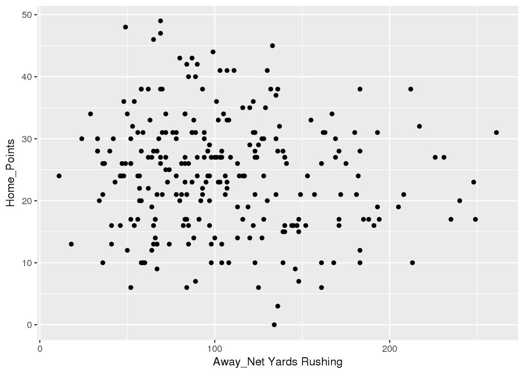

```r
 ggplot(data_2016, aes(x=`Away_Net Yards Rushing`,y=`Home_Points`)) +
   geom_point()
```

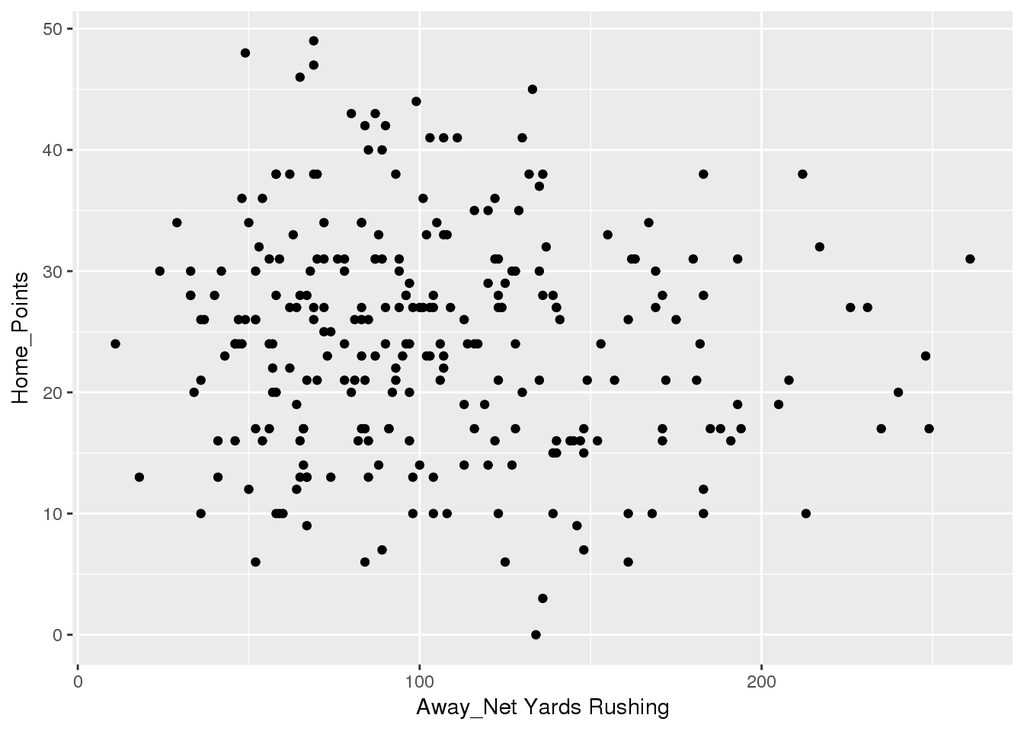

```r
 ggplot(data_2016, aes(x=`Away_Net Yards Rushing`,y=`Home_Points`)) +
  geom_point()
```

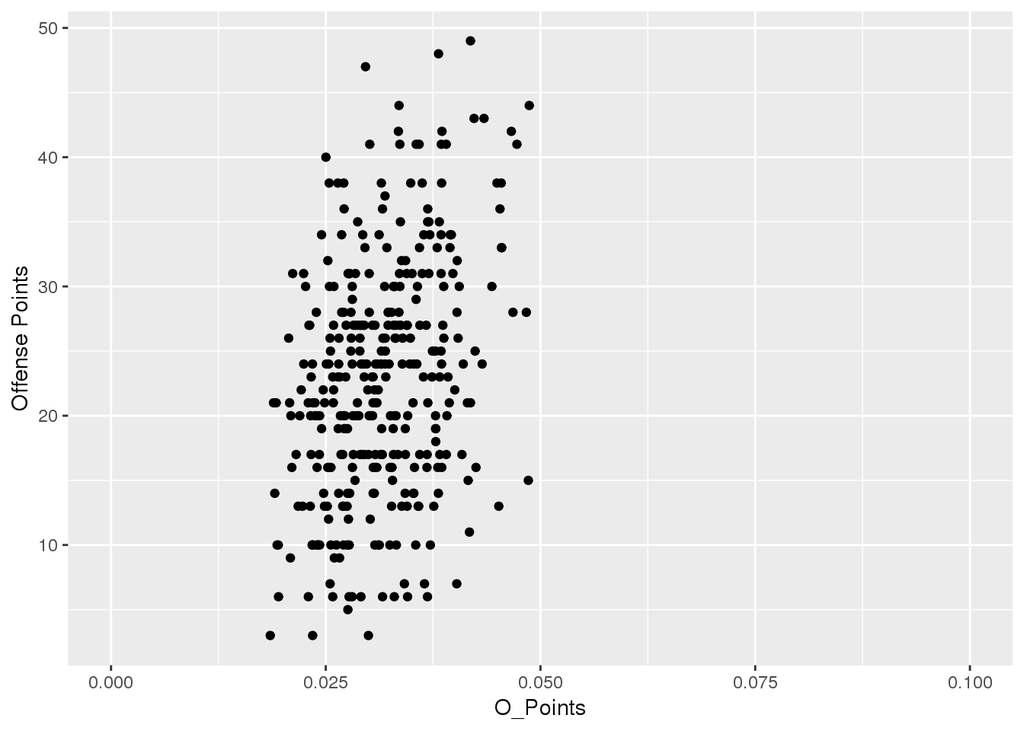

```r
ggplot(modelDF2016Filt, aes(x=`O_Points`,y=`Offense Points`)) +
  geom_point() +
  xlim(0,.1)
```

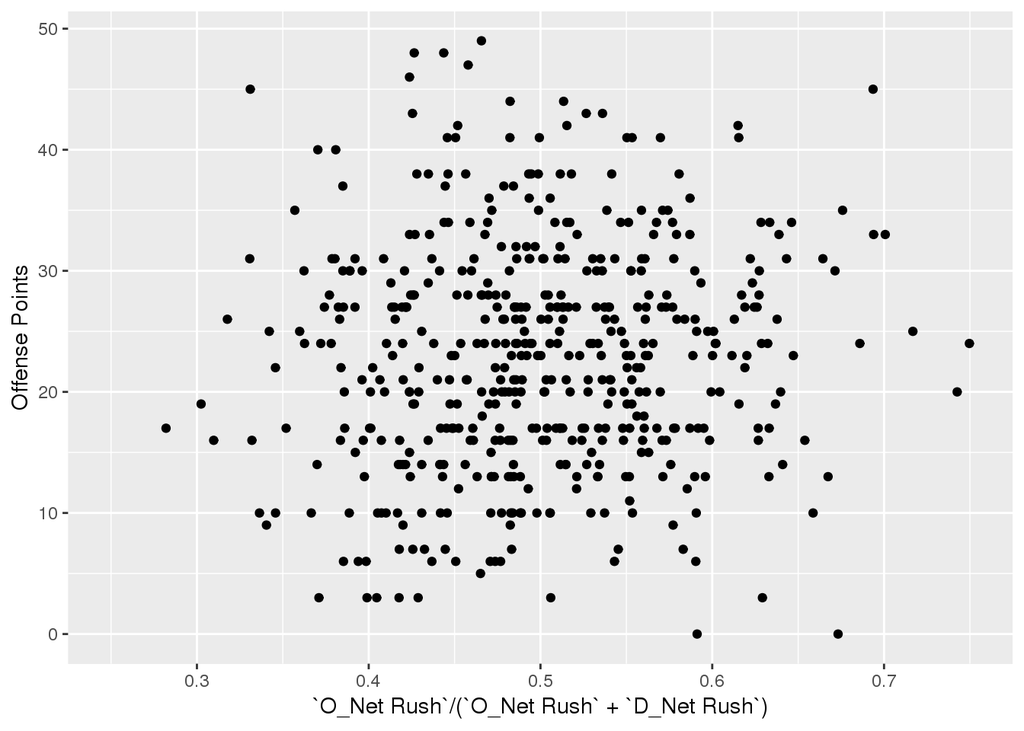

```r
ggplot(modelDF2016, aes(x=`O_Net Rush`/(`O_Net Rush` +`D_Net Rush`),y=`Offense Points`)) +
  geom_point() +
  xlim(0.25,.75)
```

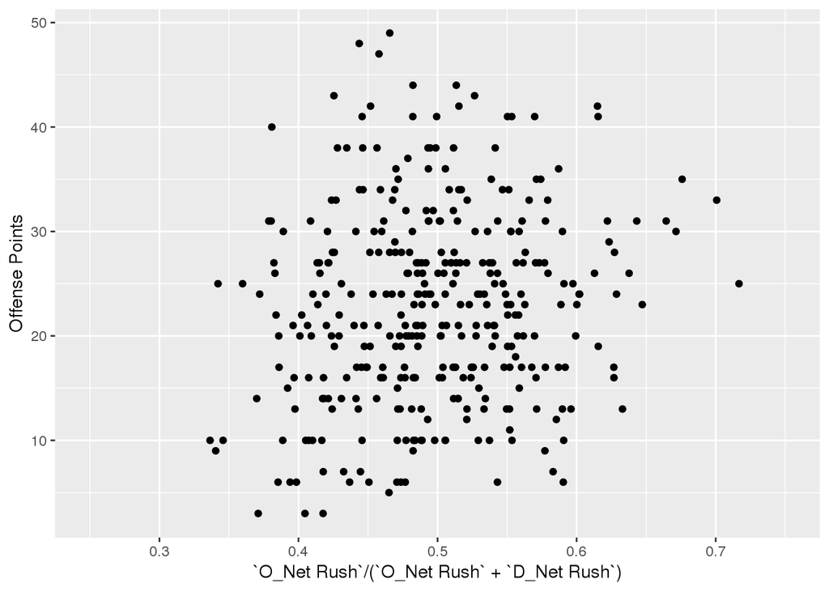

```r
ggplot(modelDF2016Filt, aes(x=`O_Net Rush`/(`O_Net Rush` +`D_Net Rush`),y=`Offense Points`)) +
  geom_point() +
  xlim(0.25,.75)
```

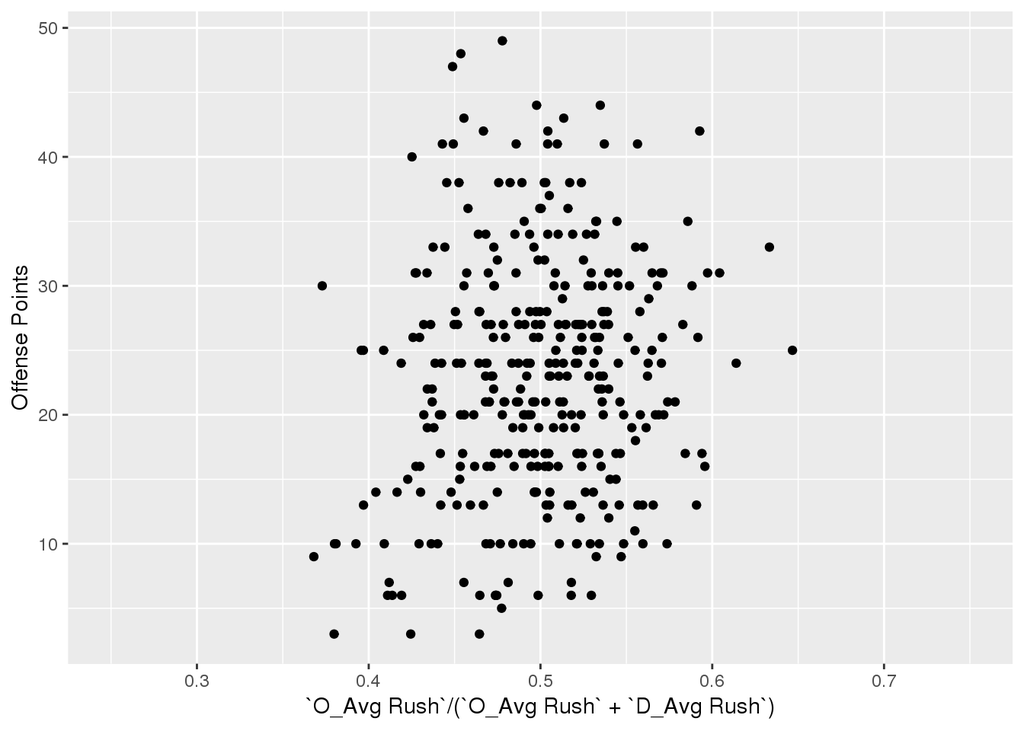

```r
ggplot(modelDF2016Filt, aes(x=`O_Avg Rush`/(`O_Avg Rush` +`D_Avg Rush`),y=`Offense Points`)) +
  geom_point() +
  xlim(0.25,.75)
```

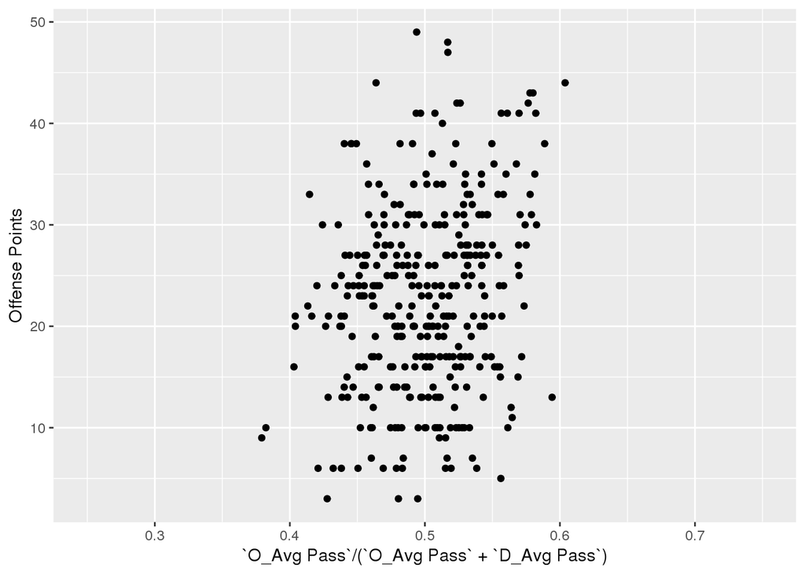

```r
ggplot(modelDF2016Filt, aes(x=`O_Avg Pass`/(`O_Avg Pass` +`D_Avg Pass`),y=`Offense Points`)) +
  geom_point() +
  xlim(0.25,.75)
```

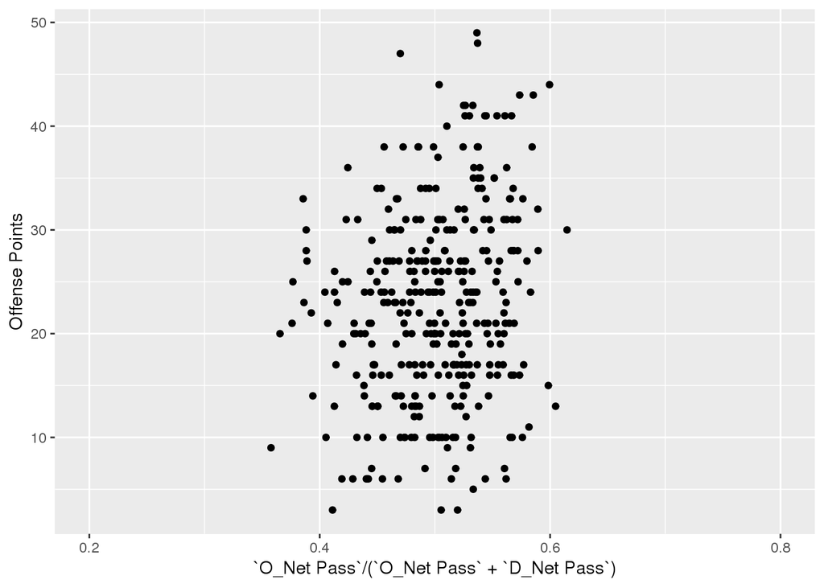

```r
ggplot(modelDF2016Filt, aes(x=`O_Net Pass`/(`O_Net Pass` +`D_Net Pass`),y=`Offense Points`)) +
  geom_point() +
  xlim(.2,.8)
```

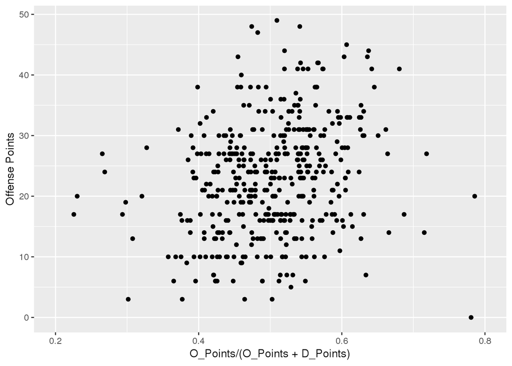

```r
ggplot(filter(modelDF2016,Week>3), aes(x=`O_Points`/(`O_Points` +`D_Points`),y=`Offense Points`)) +
  geom_point()+
  xlim(.2,.8)
```

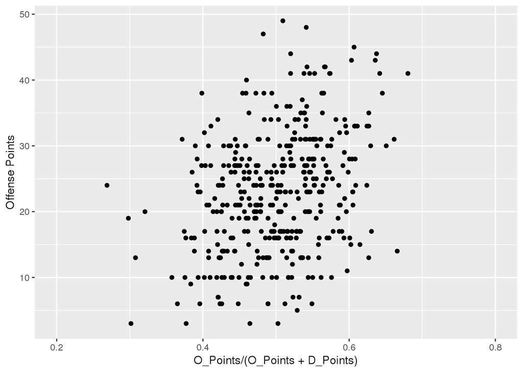

```r
ggplot(filter(modelDF2016,Week>4), aes(x=`O_Points`/(`O_Points` +`D_Points`),y=`Offense Points`)) +
  geom_point()+
  xlim(.2,.8)
```

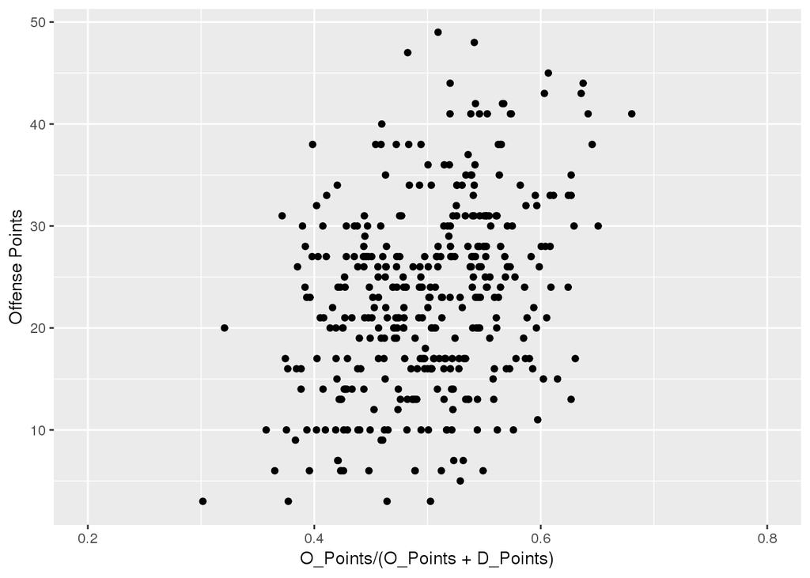

```r
ggplot(filter(modelDF2016,Week>5), aes(x=`O_Points`/(`O_Points` +`D_Points`),y=`Offense Points`)) +
  geom_point()+
  xlim(.2,.8)
```

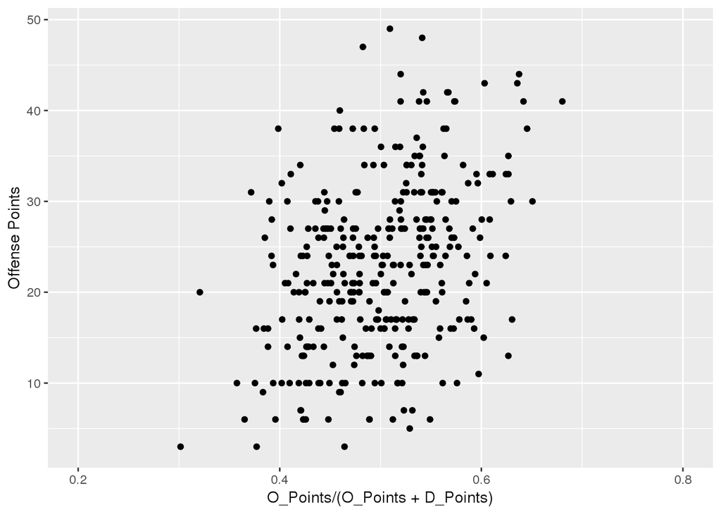

```r
ggplot(filter(modelDF2016,Week>6), aes(x=`O_Points`/(`O_Points` +`D_Points`),y=`Offense Points`)) +
  geom_point()+
  xlim(.2,.8)
```

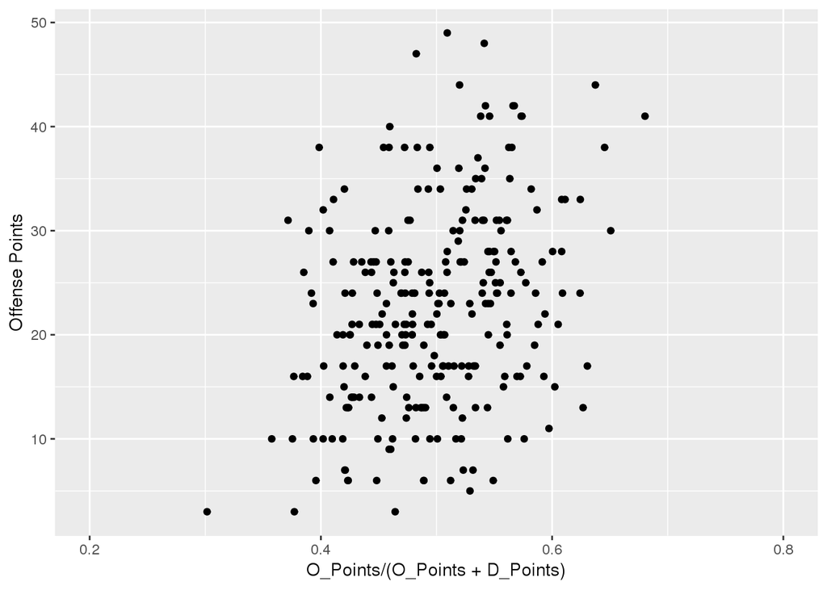

```r
ggplot(filter(modelDF2016,Week>9), aes(x=`O_Points`/(`O_Points` +`D_Points`),y=`Offense Points`)) +
  geom_point()+
  xlim(.2,.8)
```

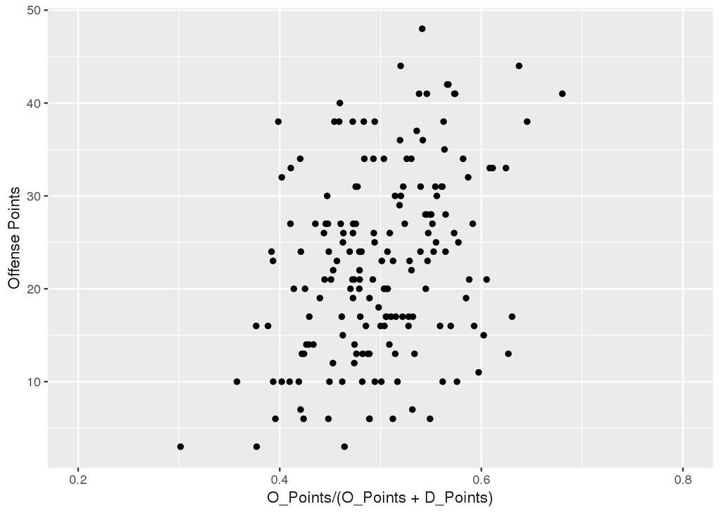

```r
ggplot(filter(modelDF2016,Week>12), aes(x=`O_Points`/(`O_Points` +`D_Points`),y=`Offense Points`)) +
  geom_point()+
  xlim(.2,.8)
```

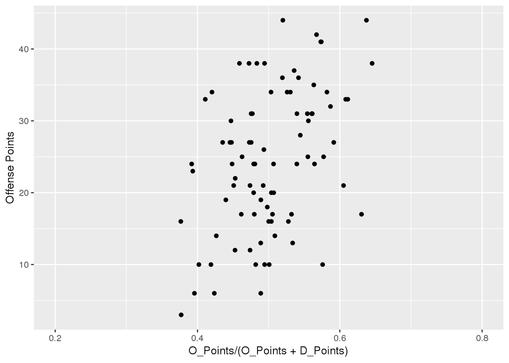

```r
ggplot(filter(modelDF2016,Week>15), aes(x=`O_Points`/(`O_Points` +`D_Points`),y=`Offense Points`)) +
  geom_point()+
  xlim(.2,.8)
```

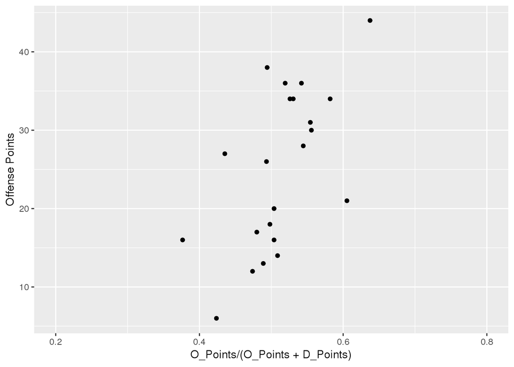

```r
ggplot(filter(modelDF2016,Week>17), aes(x=`O_Points`/(`O_Points` +`D_Points`),y=`Offense Points`)) +
  geom_point()+
  xlim(.2,.8)
```

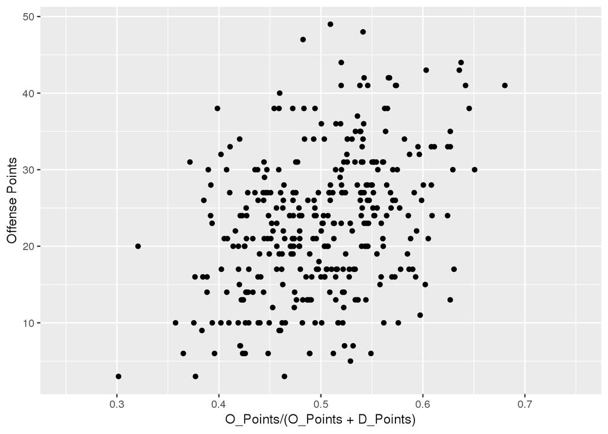

```r
ggplot(modelDF2016Filt, aes(x=`O_Points`/(`O_Points` +`D_Points`),y=`Offense Points`)) +
  geom_point() +
  xlim(0.25,.75)
```

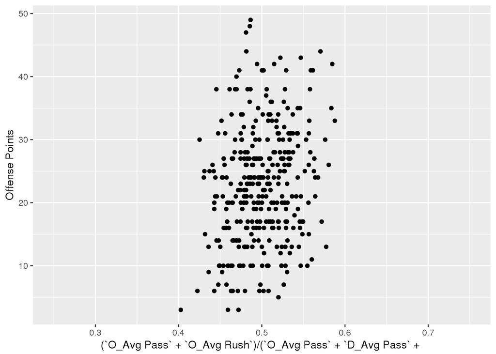

```r
ggplot(modelDF2016Filt, aes(x=(`O_Avg Pass` + `O_Avg Rush`)/(`O_Avg Pass` +`D_Avg Pass`+`O_Avg Rush` +`D_Avg Rush` ),y=`Offense Points`)) +
  geom_point() +
  xlim(0.25,.75)
```

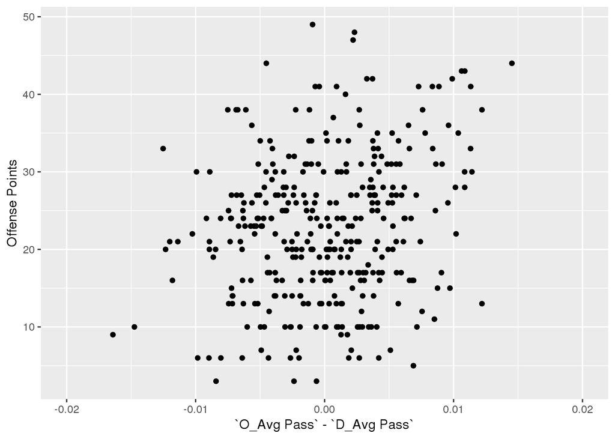

```r
ggplot(modelDF2016Filt, aes(x=`O_Avg Pass` - `D_Avg Pass`,y=`Offense Points`)) +
  geom_point() +
  xlim(-.02,.02)
```

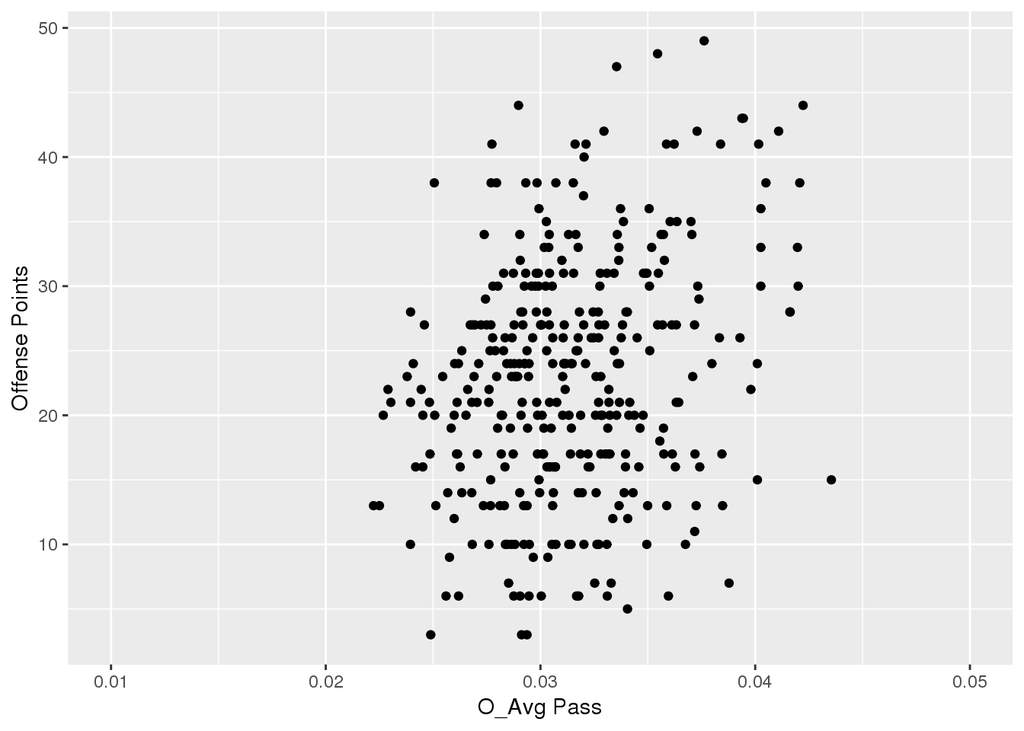

```r
ggplot(modelDF2016Filt, aes(x=`O_Avg Pass`,y=`Offense Points`)) +
  geom_point() +
  xlim(0.01,.05)
```

## Updated Models & Variables Broken Down

### Variables

- Y_i is our dependent variable for the number of points scored by the offensive team in game i.
- x_i is our variable representing the offensive team’s offensive score. This represents their ability to score points relative to the opponents deffensive score and is a representation of all the teams scoring ability.
- w_i is our variable representing the deffensive score of the opposing team. This represents that teams ability to prevent the scoring of points relative to the other teams and the offensive team they are playing.

### Models

```r
modelDF2014 <- filter(modelDF2014, Week>5)
modelDF2015 <- filter(modelDF2015,Week>5)
```

```r
modelData <-modelDF2014 %>% bind_rows(modelDF2015)  #Data filtered to later weeks to avoid noise
main1 <- "model{
  #Data
  for(i in 1:length(y)) {
       y[i] ~ dpois(mu[i])
       log(mu[i]) <- b0 + b1*(x[i]/(x[i]+w[i])) + b10*h[i]
  }

  #Priors
  b0 ~ dnorm(0,1/10)
  b1 ~ dnorm(1,1/10)
  b10 ~ dnorm(3,1)

}"


main1_jags <- jags.model(textConnection(main1),
               data= list(y=modelData$`Offense Points`, x=modelData$O_Points, w=modelData$D_Points, h=modelData$`Is Home`),
                    inits=list(.RNG.name="base::Wichmann-Hill", .RNG.seed=1989))
main1_sim <- coda.samples(main1_jags, variable.names=c("b0","b1","b10"), n.iter=10000)

main1_sample <- data.frame(step=1:10000, main1_sim[[1]])
head(main1_sample)
```

```
##   step       b0       b1        b10
## 1    1 2.030926 2.046803 0.09202098
## 2    2 2.022671 2.067055 0.10805614
## 3    3 2.004993 2.103864 0.10604442
## 4    4 2.004739 2.096879 0.09218309
## 5    5 2.005673 2.100194 0.09186392
## 6    6 2.012726 2.075176 0.11062526
```

```r
summary(main1_sim)
```

```
##
## Iterations = 1001:11000
## Thinning interval = 1
## Number of chains = 1
## Sample size per chain = 10000
##
## 1. Empirical mean and standard deviation for each variable,
##    plus standard error of the mean:
##
##        Mean      SD  Naive SE Time-series SE
## b0  2.11666 0.05718 0.0005718      0.0073024
## b1  1.87595 0.10987 0.0010987      0.0134805
## b10 0.09809 0.01509 0.0001509      0.0003139
##
## 2. Quantiles for each variable:
##
##        2.5%     25%     50%    75%  97.5%
## b0  1.99698 2.07954 2.12283 2.1576 2.2146
## b1  1.68483 1.79798 1.86628 1.9455 2.1054
## b10 0.06929 0.08798 0.09791 0.1082 0.1278
```

```r
set.seed(13)
predictmain1 <- function(x,w,h){
  prediction <- rpois(10000,exp(main1_sample$b0 + main1_sample$b1*(x/(x+w)) + main1_sample$b10*h))
}

comparePrediction <- function(scores,O_data,D_data,is_home){
  vals = rep(0,length(scores))
  for(i in 1:length(scores)){
    actualScore = scores[i]
    prediction = predictmain1(O_data[i],D_data[i],is_home[i])
    vals[i]=actualScore-prediction
  }
  return(vals)

}
```

```r
modelData2016 <- filter(modelDF2016,Week>5)
predictionAccuracy = data.frame(comparePrediction(modelData2016[,4],modelData2016[,9],modelData2016[,19],modelData2016[,24]))
```

[output not shown]

[output cut: 1084 more lines]

[output not shown]

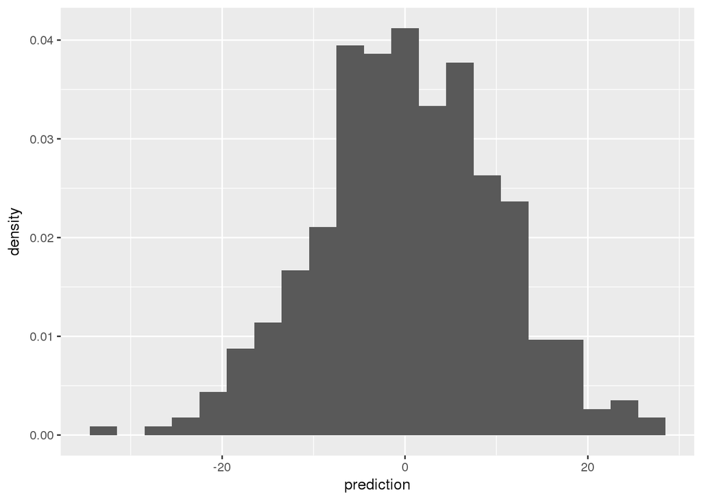

```r
# View(modelDF2016)

colnames(predictionAccuracy)[1]<- "prediction"
ggplot(predictionAccuracy, aes(x=prediction)) + geom_histogram(binwidth = 3, aes(y=..density..))
```

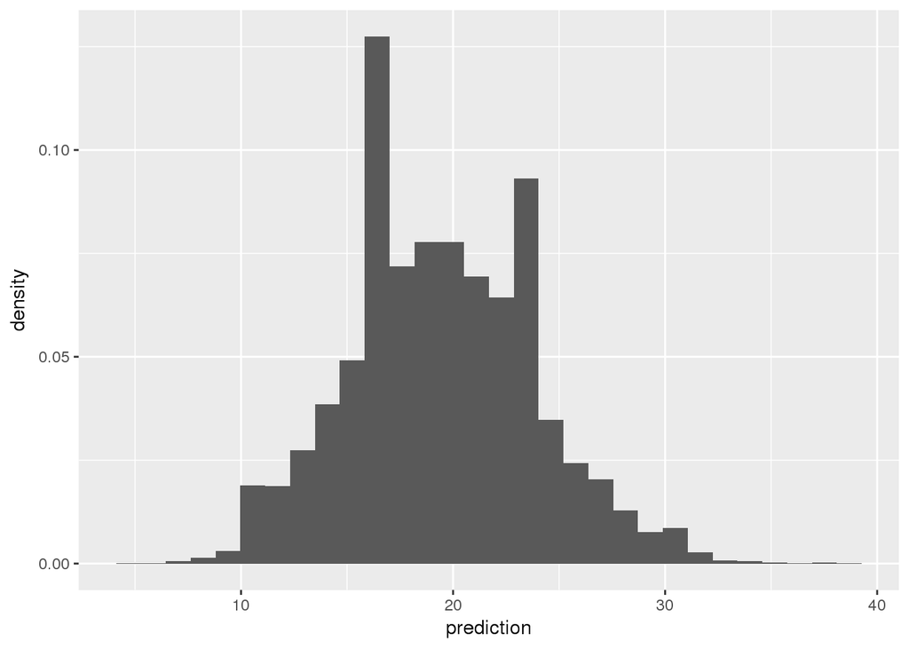

```r
set.seed(1989)
main_predict1 = data.frame(predictmain1(.04045,0.04835,0))
colnames(main_predict1)[1]<- "prediction"

ggplot(main_predict1, aes(x=prediction)) + geom_histogram(aes(y=..density..))
```

```r
modelData <-filter(modelDF2016,Week>5)

#Model main1_1 is a Poisson normal regression
main1_1 <- "model{
  #Data
  for(i in 1:length(y)) {
      y[i] ~ dpois(lam[i])
      lam[i] ~ dnorm(mu[i],tau)
      mu[i] <- b0 + b1*(x[i]/(x[i]+w[i])) + b10*h[i]
  }

  #Priors
  b0 ~ dnorm(0,1/10)
  b1 ~ dnorm(1,1/10)
  b10 ~ dnorm(3,1)
  tau ~ dgamma(1,1/10)


}"


main1_1_jags <- jags.model(textConnection(main1_1),
               data= list(y=modelData$`Offense Points`, x=modelData$O_Points, w=modelData$D_Points, h=modelData$`Is Home`),
                    inits=list(.RNG.name="base::Wichmann-Hill", .RNG.seed=1989))
main1_1_sim <- coda.samples(main1_1_jags, variable.names=c("b0","b1","b10","tau"), n.iter=10000)

main1_1_sample <- data.frame(step=1:10000, main1_1_sim[[1]])
head(main1_1_sample)
```

```
##   step       b0       b1      b10        tau
## 1    1 10.84277 19.33583 3.955409 0.02036338
## 2    2 11.14979 19.68063 3.285330 0.02014019
## 3    3 11.50895 17.35052 4.705818 0.01991978
## 4    4 11.96631 14.55820 4.469761 0.01886457
## 5    5 12.48212 14.85823 3.929060 0.02126191
## 6    6 12.98788 15.83685 3.287589 0.01759012
```

```r
summary(main1_1_sim)
```

```
##
## Iterations = 1001:11000
## Thinning interval = 1
## Number of chains = 1
## Sample size per chain = 10000
##
## 1. Empirical mean and standard deviation for each variable,
##    plus standard error of the mean:
##
##         Mean       SD  Naive SE Time-series SE
## b0  13.52663 1.458430 1.458e-02      7.346e-02
## b1  14.88295 2.751889 2.752e-02      1.430e-01
## b10  3.34009 0.670093 6.701e-03      1.173e-02
## tau  0.01831 0.001857 1.857e-05      3.545e-05
##
## 2. Quantiles for each variable:
##
##         2.5%      25%      50%      75%    97.5%
## b0  10.78589 12.55248 13.46388 14.50182 16.41921
## b1   9.36325 13.07342 14.95410 16.75116 20.21545
## b10  2.02969  2.87842  3.34297  3.78834  4.65109
## tau  0.01495  0.01701  0.01823  0.01951  0.02222
```

```r
set.seed(1989)
predictmain1_1 <- function(x,w,h){
  rate <- rnorm(10000, main1_1_sample$b0 + main1_1_sample$b1*(x/(x+w)) + main1_1_sample$b10*h, sqrt(main1_1_sample$tau^{-1}))
  rate<-rate[rate>0]
  prediction <- rpois(10000,rate)
}

head(predictmain1_1(.04835,.04045,0))
```

```
## [1] 24 23  7 19 17 15
```

```r
mean(predictmain1_1(.04835,.04045,0))
```

```
## [1] 21.7251
```

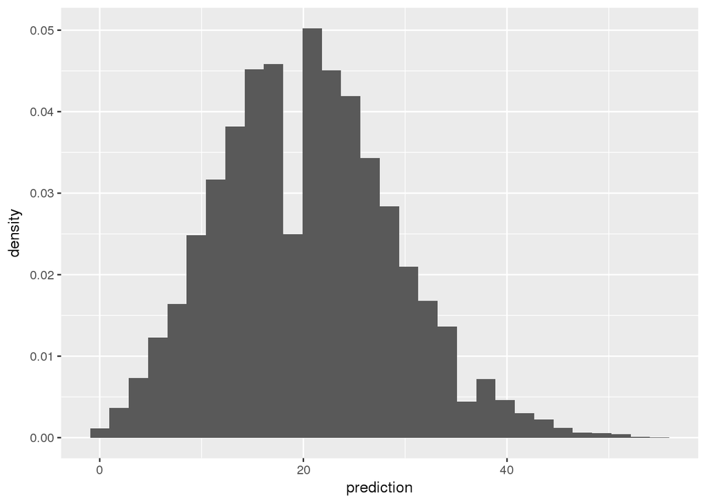

```r
set.seed(1989)
main_predict1_1 = data.frame(predictmain1_1(.04045,0.04835,0))
colnames(main_predict1_1)[1]<- "prediction"

ggplot(main_predict1_1, aes(x=prediction)) + geom_histogram(aes(y=..density..))
```